# dbishop7Mod5

```python
import pandas as pd

# Load the datasets
red_wine = pd.read_csv('./data/red.csv')
white_wine = pd.read_csv('./data/white.csv')

print("Red Wine Dataset Preview:")
print(red_wine.head())
print("\nWhite Wine Dataset Preview:")
print(white_wine.head())
```

```
Red Wine Dataset Preview:
   fixed_acidity  volatile_acidity  citric_acid  residual_sugar  chlorides  \
0            7.4              0.70         0.00             1.9      0.076
1            7.8              0.88         0.00             2.6      0.098
2            7.8              0.76         0.04             2.3      0.092
3           11.2              0.28         0.56             1.9      0.075
4            7.4              0.70         0.00             1.9      0.076

   free_sulfur_dioxide  total_sulfur_dioxide  density    pH  sulphates  \
0                 11.0                  34.0   0.9978  3.51       0.56
1                 25.0                  67.0   0.9968  3.20       0.68
2                 15.0                  54.0   0.9970  3.26       0.65
3                 17.0                  60.0   0.9980  3.16       0.58
4                 11.0                  34.0   0.9978  3.51       0.56

   alcohol  quality
0      9.4        5
1      9.8        5
2      9.8        5
3      9.8        6
4      9.4        5

White Wine Dataset Preview:
   fixed_acidity  volatile_acidity  citric_acid  residual_sugar  chlorides  \
0            7.0              0.27         0.36            20.7      0.045
1            6.3              0.30         0.34             1.6      0.049
2            8.1              0.28         0.40             6.9      0.050
3            7.2              0.23         0.32             8.5      0.058
4            7.2              0.23         0.32             8.5      0.058

   free_sulfur_dioxide  total_sulfur_dioxide  density    pH  sulphates  \
0                 45.0                 170.0   1.0010  3.00       0.45
1                 14.0                 132.0   0.9940  3.30       0.49
2                 30.0                  97.0   0.9951  3.26       0.44
3                 47.0                 186.0   0.9956  3.19       0.40
4                 47.0                 186.0   0.9956  3.19       0.40

   alcohol  quality
0      8.8        6
1      9.5        6
2     10.1        6
3      9.9        6
4      9.9        6
```

```python
# Task 1: Calculate mean and standard deviation for the quality of white wine
mean_quality_white = white_wine['quality'].mean()
std_dev_quality_white = white_wine['quality'].std()

print(f"Mean Quality of White Wine: {mean_quality_white}")
print(f"Standard Deviation of White Wine Quality: {std_dev_quality_white}")
```

```
Mean Quality of White Wine: 5.87790935075541
Standard Deviation of White Wine Quality: 0.8856385749678312
```

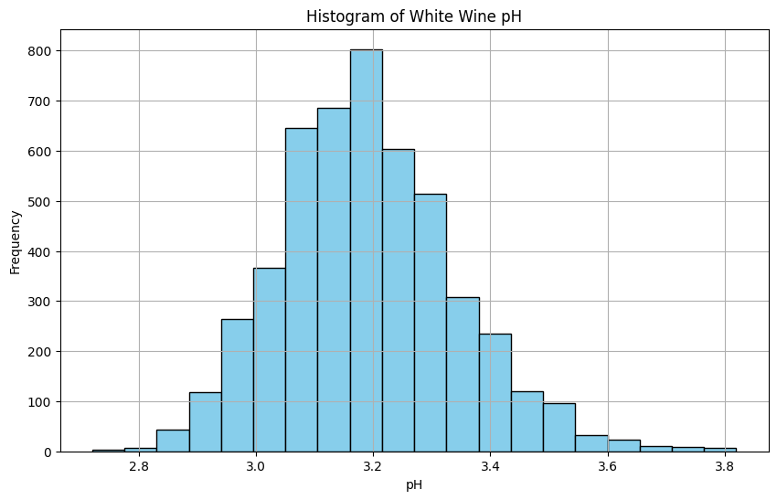

```python
import matplotlib.pyplot as plt

# Task 2: Plotting the histogram for the pH values of white wine
plt.figure(figsize=(10, 6))
plt.hist(white_wine['pH'], bins=20, color='skyblue', edgecolor='black')
plt.title('Histogram of White Wine pH')
plt.xlabel('pH')
plt.ylabel('Frequency')
plt.grid(True)
plt.show()
```

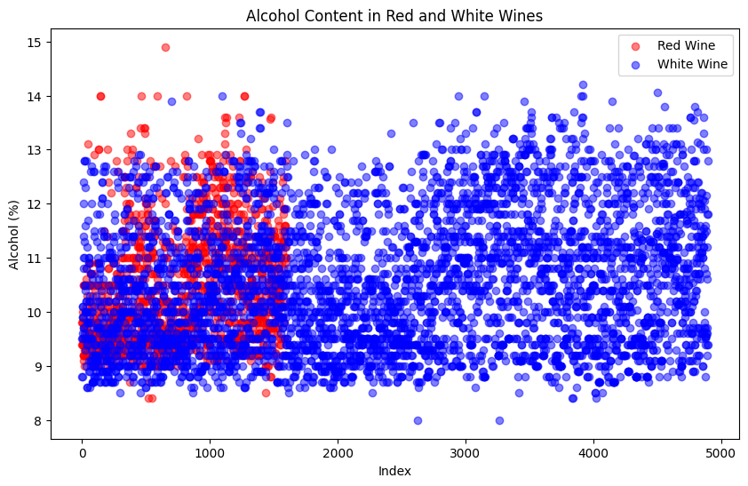

```python
import matplotlib.pyplot as plt

# Task 3: Create a scatter plot for alcohol content
plt.figure(figsize=(10, 6))
plt.scatter(red_wine.index, red_wine['alcohol'], color='red', alpha=0.5, label='Red Wine')
plt.scatter(white_wine.index, white_wine['alcohol'], color='blue', alpha=0.5, label='White Wine')

plt.title('Alcohol Content in Red and White Wines')
plt.xlabel('Index')
plt.ylabel('Alcohol (%)')
plt.legend()
plt.show()
```

```python
from sklearn.model_selection import train_test_split
from sklearn.linear_model import LogisticRegression
from sklearn.metrics import classification_report
import pandas as pd

# Combine the datasets with a new column 'color' for wine type
red_wine['color'] = 0  # Red wine
white_wine['color'] = 1  # White wine
wines = pd.concat([red_wine, white_wine], ignore_index=True)

# Split the data into features and target variable
X = wines.drop(['color'], axis=1)  # Features
y = wines['color']  # Target variable

#Fill blank variables so training does crash
X = X.fillna(X.median())

# Split the dataset into training and test sets
X_train, X_test, y_train, y_test = train_test_split(X, y, test_size=0.3)

# Task 4: Initialize and train the logistic regression model
model = LogisticRegression(max_iter=1000)
model.fit(X_train, y_train)

# Print the coefficients and intercept
print("Intercept:", model.intercept_)
print("Coefficients:", model.coef_)

# Predict on the test set and print the classification report
predictions = model.predict(X_test)
print(classification_report(y_test, predictions))
```

```
Intercept: [23.64246588]
Coefficients: [[-1.07313791 -7.78029394  0.62883976  0.09731252 -2.64998076 -0.0394345
   0.0554712  -0.24689729 -5.72720672 -5.8207153   0.53455443  0.06119232]]
              precision    recall  f1-score   support

           0       0.99      0.96      0.97       505
           1       0.99      1.00      0.99      1445

    accuracy                           0.99      1950
   macro avg       0.99      0.98      0.98      1950
weighted avg       0.99      0.99      0.99      1950
```

```python
import statsmodels.api as sm

# Prepare the data with an intercept added to the features
X_with_intercept = sm.add_constant(X_train)

# Fit the logistic regression model using statsmodels
logit_model = sm.Logit(y_train, X_with_intercept)
result = logit_model.fit()

p_values = result.pvalues.drop('const')  # Drop the p-value for the intercept, I felt like const wasn't necessary as a datapoint

# Print the summary of the model to get the coefficients and p-values
print("P-values of the model coefficients:")
print(p_values.map('{:.5f}'.format))

significant_p_values = p_values[p_values < 0.05]
print("Significant p-values (p < 0.05):")
print(significant_p_values.map('{:.5f}'.format))
```

```
Optimization terminated successfully.
         Current function value: 0.035434
         Iterations 14
P-values of the model coefficients:
fixed_acidity           0.47679
volatile_acidity        0.00000
citric_acid             0.10032
residual_sugar          0.00000
chlorides               0.00000
free_sulfur_dioxide     0.00226
total_sulfur_dioxide    0.00000
density                 0.00000
pH                      0.85311
sulphates               0.00794
alcohol                 0.00001
quality                 0.06014
dtype: object
Significant p-values (p < 0.05):
volatile_acidity        0.00000
residual_sugar          0.00000
chlorides               0.00000
free_sulfur_dioxide     0.00226
total_sulfur_dioxide    0.00000
density                 0.00000
sulphates               0.00794
alcohol                 0.00001
dtype: object
```

## Important P Values

As we can note above there are 8 different P values that are "most important" for the model to determine Wine Color. These are volatile_acidity, residual_sugar, chlorides, free_sulfur_dioxide, total_sulfur_dioxide, density, sulphates, and alcohol.

```python
from sklearn.ensemble import RandomForestClassifier
from sklearn.model_selection import StratifiedKFold, cross_val_score
from sklearn.metrics import make_scorer, accuracy_score, cohen_kappa_score

# Initialize the Random Forest classifier
rf_classifier = RandomForestClassifier(n_estimators=100)

# Set up Stratified K-Fold cross-validation
skf = StratifiedKFold(n_splits=5, shuffle=True)

accuracy_scorer = make_scorer(accuracy_score)
kappa_scorer = make_scorer(cohen_kappa_score)

# Perform cross-validation for accuracy
accuracy_scores = cross_val_score(rf_classifier, X, y, cv=skf, scoring=accuracy_scorer)
highest_accuracy = max(accuracy_scores)

# Perform cross-validation for kappa
kappa_scores = cross_val_score(rf_classifier, X, y, cv=skf, scoring=kappa_scorer)
average_kappa = kappa_scores.mean()

print(f"Highest Accuracy from cross-validation: {highest_accuracy:.4f}")
print(f"Average Kappa from cross-validation: {average_kappa:.4f}")
```

```
Highest Accuracy from cross-validation: 0.9985
Average Kappa from cross-validation: 0.9854
```

```python
from sklearn.tree import DecisionTreeClassifier
from sklearn.model_selection import cross_val_score, StratifiedKFold
from sklearn.metrics import classification_report

# Initialize the CART model (Decision Tree Classifier)
cart_classifier = DecisionTreeClassifier()

# Set up Stratified K-Fold cross-validation
skf = StratifiedKFold(n_splits=5, shuffle=True)

# Perform cross-validation for accuracy
accuracy_scores = cross_val_score(cart_classifier, X, y, cv=skf, scoring='accuracy')

# Fit the model on the entire dataset for a detailed classification report
cart_classifier.fit(X_train, y_train)
y_pred = cart_classifier.predict(X_test)

# Detailed classification report
class_report = classification_report(y_test, y_pred)

print(f"Cross-Validated Accuracy: {accuracy_scores.mean():.4f}")
print("Classification Report:\n", class_report)
```

```
Cross-Validated Accuracy: 0.9852
Classification Report:
               precision    recall  f1-score   support

           0       0.97      0.97      0.97       505
           1       0.99      0.99      0.99      1445

    accuracy                           0.99      1950
   macro avg       0.98      0.98      0.98      1950
weighted avg       0.99      0.99      0.99      1950
```

## Different Models

In this notebook I utilized three different models per instruction, a Logistic Regressor, Random Forest, and a CART model (specifically Decision Tree Classifier). Each model has their pros and cons and can be used for different datasets to varying degrees of effectiveness. So the Logistic Regressor, it was able to perform fairly well at 98% for precision, recall, and f1-scores. This makes sense as Logistic Regressors are made for binary classifiaction, which this is. It seems to have been capable of determining patterns in the data, most likely with the low P score valued items mentioned earlier. Random Forest Classifier was the next model trained on this dataset. It was able to perform fairly well as well getting a highest accuracy score of 99% and a kappa of 98.5%. Again this makes sense as it creates multiple decision trees in which it averages decisions from to help it determine what group something should belong to. Luckily this dataset is fairly small as compared to Logistic Regression it can get a little more computationally expensive (not too bad though in my experience). Finally I trained a Decision Tree Classifier. This is fairly similar to the Random Forest model however it focuses more on making one tree to make decisions instead of averaging many. Much like the Random Forest model it had high scores in everything including accuracy, precision, recall, and f1-score. As this was a fairly simple dataset we didn't need to worry about overfitting too badly and it worked out for this model quite well. Overall, each model was able to perform quite well on this dataset.